# Five dots

##### *Authors: Group 4*

- *Clauwers, Jaimy J.W.L.*
- *van der Eerden, Marjolein M.C.*
- *Umwiza, Soleil S.*

## 🟡 Phase 1: Proposal

### 🟡 Domain understanding

#### 🏫 Maastricht University

Maastricht University (Universiteit Maastricht) is a well-known Dutch university located in the city of Maastricht, the Netherlands. The university is renowned for its international character and innovative educational methods. Maastricht University has multiple faculties and offers a wide range of bachelor's, master's, and PhD programs in various fields, including medicine and health sciences, law, economics, arts, and social sciences.

The university is also recognized for its Problem-Based Learning (PBL) approach, which encourages students to actively participate in their own learning process and tackle complex issues. Maastricht University is highly ranked in international rankings and attracts students and academics from around the world. It is a leading institution of higher education in the Netherlands and Europe.

> About UM - About UM - Maastricht University. (n.d.). https://www.maastrichtuniversity.nl/about-um-0

#### 🎲The Five Dot Test

The Five Dot Test, also known as the Design Fluency Test, is a cognitive assessment tool designed to measure an individual's ability to generate as many diverse and original designs as possible within a specific time period, using a limited set of shapes and lines. The test typically involves displaying a grid with five dots and connecting these dots to create unique patterns.

The Five Dot Test is often used in research to explore various aspects of cognitive function, including:

- **Executive Functions**: The test can provide insights into a person's capacity to apply strategic thinking processes when generating designs.
- **Working Memory**: The ability to remember the five dots and use them in creating designs.
- **Creative Thinking**: The ability to come up with original and diverse designs within the given constraints.

The Five Dot Test is often conducted under standardized conditions, meaning there are specific instructions and time limits to ensure consistency in the assessment. It can be applied to various populations, including children, adults, and older individuals, and has valuable applications in neuropsychological research and clinical assessments.

> Tucha, L., Aschenbrenner, S., Koerts, J., & Lange, K. W. (2012). The Five-Point Test: reliability, validity and normative data for children and adults. PLOS ONE, 7(9), e46080. https://doi.org/10.1371/journal.pone.0046080

The traditional scoring method involves assigning a specific time interval (e.g., 90 seconds) and then counting all the unique patterns generated, subtracting any duplicates.

> Cognitive scheme: https://app.diagrams.net/#G1ZnMBsSesW0elvxvbbAYP8drdYvStngMT

#### 📄Test at primary school (Eindtoets)

The "Eindtoets op de basisschool," known in English as the "Final Primary School Test" or "Primary School Leaving Examination," is a standardized test typically administered at the end of the primary school period. This test is designed to assess the academic level and knowledge of students and determine if they are ready to progress to secondary education.

Key points about the Final Primary School Test, including an explanation of the scoring range and associated recommendations, are as follows:

- **Evaluation of Basic Skills**: The test usually assesses core skills that students have acquired during their primary school education, such as reading, writing, mathematics, and comprehension.
- **Level of Proficiency**: It measures the level of proficiency in these basic skills and assesses whether students are adequately prepared to enter the next phase of their education.
- **Study Advice**: The results of the Final Primary School Test are often used to provide students with study advice for secondary education. Depending on their performance, students may be recommended for different levels or streams in secondary education.
- **Standardized**: The test is standardized, meaning that all students answer the same questions under similar conditions. This helps in the objective assessment of performance.
- **Scoring Range**: The scoring of the Final Primary School Test typically falls within a specific range, such as 500 to 550 points. The exact range may vary by country.

A score in the range of 500-550 points often corresponds to specific recommendations for secondary education. For instance, a score in the upper range might lead to a recommendation for more academically challenging programs, while a score at the lower end could suggest a different educational track. These recommendations help guide students towards a suitable level or stream in their secondary education.

The Final Primary School Test represents a significant moment for students, parents, and educators, as it influences the transition to further education and provides students with an opportunity to showcase their academic achievements and receive tailored advice for their educational path.

> Cito toets: a guide to the Dutch primary school exams. (2023, February 16). Expatica. Retrieved October 8, 2023, from https://www.expatica.com/nl/education/children-education/cito-toets-exams-100820/

#### 💥Impact of AI

The impact of artificial intelligence (AI) in the field of standardized tests, such as the Primary School Leaving Examination, can be both positive and negative

##### 📈Positive impact

**Efficiency and Accuracy**: can contribute to more efficient test management, including automatic scoring. This can improve the speed of the evaluation process and reduce human errors.

**Adaptive Testing**: AI can enable adaptive testing, where the difficulty of questions adjusts to the student's level. This provides tailored questions that more accurately measure their skills.

**Quick Results**: AI-assisted assessment can provide faster access to results, allowing students, parents, and teachers to receive feedback earlier.

**Performance Analysis**: AI can help analyze performance data on a larger scale, enabling educational institutions to identify trends and improve curricula.

#### 📉Negative impact

**Bias and Fairness: If** AI systems are not well-designed, they can contain inherent biases, potentially leading to unfair results, especially for minority groups.

**Privacy Concerns**: : Collecting and storing data for AI-based tests can raise privacy concerns, particularly for tests that require personal information.

**Loss of Human Interaction**: The use of AI can lead to reduced human interaction, which may be important for understanding students' emotional needs and providing support.

**Accessibility**: While AI-adaptive tests can be beneficial, measures need to be taken to ensure that all students have access to the necessary technology and that accommodations are made for individuals with special needs.

### 🟡 Data Sourcing

We have received a number of datasets from The University of Maastricht, which will enable us to bring the project to a successful conclusion. The datasets are as follows:

- **Ozdb_fivepoints_vo3_2019-2020_vo4_2020-2021.csv**: Main dataset, contains all data on the five dot tests performed.
- **big5.csv**: Additional dataset, contains responses of participants on a Big 5 personality test.
- **eindtoets.csv**: Additional dataset, contains the scores of students at the test they took at the end of primary education.

#### 📚 Data Definition

##### 🔤 Data Fields

The main file: 'Ozdb_fivepoints_vo3_2019-2020_vo4_2020-2021.csv' contains the following variables:

- **primary**: Counts the order in which submitted patterns entered the server.
- **idll_vo3l**: The student identifier.
- **name**: Type of data that is stored and value the content of this data, this one is one of the following categories:
  - *patternsm*: The submitted pattern, giving a 1 for each line that is drawn and 0 for each line that is not drawn when submitting the figure.
  - *timestampsm*: How many milliseconds after the page was retrieved did the student submit the pattern.
  - *statuscl*: For each click was it an on- or an off-click.
  - *numbercl*: In what order have the lines been clicked (in theory statuscl can be derived from this. The first time a line is clicked it should be on, the second time it should be an off, …).
  - *timestampcl*: Gives for each click the unix time stamp.
  - *timestampload*: Gives thes unix time stamp for the moment the page was loaded. Timestampload + timestampload = the time the page was submitted.
- **value**: The obtained value associated with the corresponding *name*.
- **timestamp**: The time the data was stored.

### 🟡 Analytic Approach

#### 🎯 Target variable

In our context, using machine learning algorithms to analyze and understand student behavior and interactions, the choice of a target variable depends on the specific objectives of the analysis.

- **Prediction of student outcomes**: A binary variable indicating whether the student successfully completed a task or achieved a specific outcome (1 for success, 0 for failure).
- **Grouping students with similar patterns**: The output is the cluster assignment for each student. Clustering algorithms group students based on their behavior.
- **Temporal behavior patterns**: Time stamped datapoints, such as the sequence of student interactions over time. The analysis aims to understand how behavior changes over time, and the time stamps serve as the target variable.

#### 🎨 Model selection

With the provided data, various machine learning models can be applied, each with its own strengths and purposes.

- **Decision Trees and Random Forests**: They can explain key factors influencing student behavior and help in feature importance analysis.
- **Clustering Algorithms**: They help in segmenting students into groups with similar behavior, enabling tailored interventions.
- **Time Series Models**: They reveal temporal patterns and trends in student interactions, helping in understanding how behavior changes over time.
- **Reinforcement Learning**: It can optimize the learning process by suggesting the next best action for students, improving engagement and performance.

## Phase 2: Provisioning

### Data collection

```python
import sklearn
import pandas as pd
import numpy as np
import matplotlib.pyplot as plt
import seaborn as sns
import missingno as missing
from datetime import datetime

print("scikit-learn version:", sklearn.__version__)     # 1.1.3
print("pandas version:", pd.__version__)            # 1.5.1
print("seaborn version:", sns.__version__)

df1 = pd.read_csv("./Five Point Test/Ozdb_fivepoints_vo3_2019-2020_vo4_2020-2021.csv", sep=';', index_col=0)

print(df1.shape)
```

```
scikit-learn version: 1.3.1
pandas version: 2.1.1
seaborn version: 0.13.0
(1122114, 4)
```

### Data understanding

The first thing we did was globally looking at the data. we first did that by printing the data info.

```python
df1.info()
```

```
<class 'pandas.core.frame.DataFrame'>
Index: 1122114 entries, 36 to 1122174
Data columns (total 4 columns):
 #   Column      Non-Null Count    Dtype
---  ------      --------------    -----
 0   idll_vo3lv  1122114 non-null  int64
 1   name        1122114 non-null  object
 2   value       1093572 non-null  object
 3   timestamp   1122114 non-null  object
dtypes: int64(1), object(3)
memory usage: 42.8+ MB
```

We saw that there were only 4 columns where we expected more since we were told what we would get in the dataset by the clients. So next up we printed a random sample of 25 so we can see why it are only so little columns.

```python
df1.sample(25)
```

| primary | idll_vo3lv | name | value | timestamp |
| --- | --- | --- | --- | --- |
| 46110 | 9486 | timestampload | 1583927035093 | 2020-03-11 12:44:08 |
| 1098134 | 994 | timestampsm | 3477 | 2020-11-11 11:04:56 |
| 796086 | 1018 | timestampload | 1601385024273 | 2020-09-29 15:10:28 |
| 726881 | 2924 | timestampcl | 1600943434312 | 2020-09-24 12:30:35 |
| 598301 | 9858 | timestampcl | 1600248993400,1600248994424 | 2020-09-16 11:36:35 |
| 258452 | 2643 | timestampsm | 13415 | 2020-06-18 14:57:36 |
| 1044530 | 7227 | timestampsm | 3102 | 2020-11-05 15:30:59 |
| 207433 | 5630 | patternsm | 1,0,0,1,0,1,1,1 | 2020-06-17 13:19:14 |
| 295361 | 1308 | timestampcl | 1592821299084,1592821299772,1592821300332,1592... | 2020-06-22 12:21:42 |
| 576352 | 5693 | numbercl | 8,8,8,5,4,3 | 2020-09-14 15:43:24 |
| 1104450 | 1590 | timestampload | 1605174121518 | 2020-11-12 10:42:08 |
| 351284 | 7801 | timestampsm | 3748 | 2020-06-24 15:25:39 |
| 736532 | 6940 | timestampsm | 2652 | 2020-09-24 15:07:01 |
| 221703 | 8496 | statuscl | 1,1,1 | 2020-06-17 17:05:59 |
| 791312 | 8038 | timestampsm | 216 | 2020-09-29 10:56:42 |
| 679555 | 8217 | patternsm | 0,1,0,1,1,0,1,0 | 2020-09-23 08:53:35 |
| 753788 | 9943 | timestampsm | 6376 | 2020-09-25 14:55:45 |
| 366894 | 9730 | timestampload | 1593087039597 | 2020-06-25 14:10:43 |
| 895615 | 110 | patternsm | 0,0,0,0,0,1,1,0 | 2020-10-07 09:35:11 |
| 747175 | 4328 | patternsm | 0,1,0,0,0,0,0,1 | 2020-09-25 13:41:16 |
| 427773 | 1490 | statuscl | 1 | 2020-06-30 22:56:18 |
| 1078138 | 4488 | numbercl | 8,6,3 | 2020-11-06 14:50:18 |
| 791313 | 8038 | statuscl | NaN | 2020-09-29 10:56:42 |
| 843565 | 3565 | patternsm | 0,0,1,0,0,1,0,1 | 2020-10-01 14:01:38 |
| 903213 | 2602 | statuscl | 1,1 | 2020-10-07 12:26:50 |

At the data frame above i can see that the dataset is pivoted. So before we can begin to understand the data better we have to unpivot the dataset so that all the different names in the name column has its own column.

```python
# Pivoting dataframe to extract values of name column as separate columns and leaving the timestamp and idll_vo3lv as indexes
pivoted_df = df1.pivot_table(index=['idll_vo3lv', 'timestamp'], columns='name', values='value', aggfunc='first')

# Assigning pivoted_df to df to make variable name smaller
df1 = pivoted_df

df1 = df1.reset_index()[['idll_vo3lv', 'timestamp', 'numbercl', 'patternsm', 'statuscl', 'timestampcl', 'timestampload', 'timestampsm']]

df1
```

| name | idll_vo3lv | timestamp | numbercl | patternsm | statuscl | timestampcl | timestampload | timestampsm |
| --- | --- | --- | --- | --- | --- | --- | --- | --- |
| 0 | 1 | 2020-03-09 09:32:32 | 3,7 | 0,0,1,0,0,0,1,0 | 1,1 | 1583742751461,1583742751869 | 1583742749790 | 2520 |
| 1 | 1 | 2020-03-09 09:32:35 | 2,1 | 1,1,0,0,0,0,0,0 | 1,1 | 1583742753766,1583742754238 | 1583742752391 | 2576 |
| 2 | 1 | 2020-03-09 09:32:37 | 3,4 | 0,0,1,1,0,0,0,0 | 1,1 | 1583742756412,1583742756876 | 1583742755058 | 2541 |
| 3 | 1 | 2020-03-09 09:32:40 | 8,6 | 0,0,0,0,0,1,0,1 | 1,1 | 1583742759029,1583742759476 | 1583742757674 | 2540 |
| 4 | 1 | 2020-03-09 09:32:42 | 4,3 | 0,0,1,1,0,0,0,0 | 1,1 | 1583742761381,1583742762222 | 1583742760309 | 2384 |
| ... | ... | ... | ... | ... | ... | ... | ... | ... |
| 185139 | 10058 | 2020-12-04 12:15:51 | 1,5 | 1,0,0,0,1,0,0,0 | 1,1 | 1607080547519,1607080548139 | 1607080546777 | 2113 |
| 185140 | 10058 | 2020-12-04 12:15:53 | 3,8 | 0,0,1,0,0,0,0,1 | 1,1 | 1607080549806,1607080550351 | 1607080549305 | 1529 |
| 185141 | 10058 | 2020-12-04 12:15:56 | 3,7 | 0,0,1,0,0,0,1,0 | 1,1 | 1607080552454,1607080553061 | 1607080551211 | 2566 |
| 185142 | 10058 | 2020-12-04 12:15:57 | NaN | 0,0,0,0,0,0,0,0 | NaN | NaN | 1607080554234 | 875 |
| 185143 | 10058 | 2020-12-04 12:16:02 | 4,5,3 | 0,0,1,1,1,0,0,0 | 1,1,1 | 1607080555960,1607080556889,1607080559545 | 1607080555528 | 4489 |

185144 rows × 8 columns

Now that the dataset is more like we expected we can do proper data understanding. we first started by looking at the general info about the data.

```python
df1.info()
```

```
<class 'pandas.core.frame.DataFrame'>
RangeIndex: 185144 entries, 0 to 185143
Data columns (total 8 columns):
 #   Column         Non-Null Count   Dtype
---  ------         --------------   -----
 0   idll_vo3lv     185144 non-null  int64
 1   timestamp      185144 non-null  object
 2   numbercl       176414 non-null  object
 3   patternsm      182868 non-null  object
 4   statuscl       176415 non-null  object
 5   timestampcl    176411 non-null  object
 6   timestampload  182869 non-null  object
 7   timestampsm    182866 non-null  object
dtypes: int64(1), object(7)
memory usage: 11.3+ MB
```

From this we can conclude multiple things:

1. there are some null values what we have to look at.
2. there a couple of columns where you would expect a date time or another sort of time series datatype.
3. there is no score calculated(they way the would do normally with the five-point test)

#### Handling null values

```python
df1.isnull().sum()
```

```
name
idll_vo3lv          0
timestamp           0
numbercl         8730
patternsm        2276
statuscl         8729
timestampcl      8733
timestampload    2275
timestampsm      2278
dtype: int64
```

Using `sns heatmap` library to visualize missing values.

As we can see below, this figure shows which column have mising values and the relation they have with other columns.

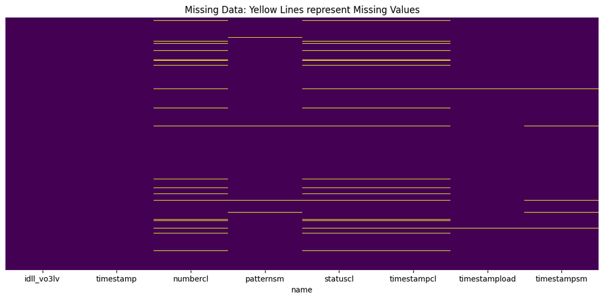

```python
plt.figure(figsize=(14, 6 ))
sns.heatmap(df1.isnull(), cmap='viridis', cbar=False, yticklabels=False)
plt.title('Missing Data: Yellow Lines represent Missing Values')
plt.show()
```

Let's also plot the relation of a presence of null value in a column to another using a `Missingno` heat map. Ref: [Visualize Missing Values](https://towardsdatascience.com/using-the-missingno-python-library-to-identify-and-visualise-missing-data-prior-to-machine-learning-34c8c5b5f009)

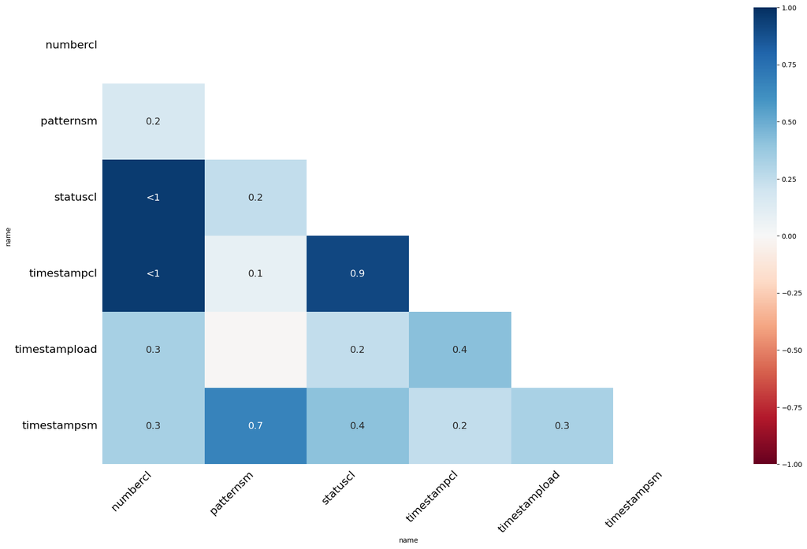

```python
import missingno as msno
msno.heatmap(df1)
```

Let's first verify if our data contains duplicates before we decide on missing data

```python
df1.duplicated().value_counts()
```

```
False    185144
Name: count, dtype: int64
```

Let's verify for how many students we have missing values We will reset the index so that we can use the column `idll_vo3lv`

```python
rows_missing_data=df1[df1.isnull().any(axis=1)]
rows_missing_data=rows_missing_data.reset_index()
len(rows_missing_data.idll_vo3lv.unique())
```

```
3268
```

#### Converting time series data

```python
# Convert columns to proper datatypes
df1['timestamp'] = pd.to_datetime(df1['timestamp'])

# Check the updated data types
df1.dtypes
```

```
name
idll_vo3lv                int64
timestamp        datetime64[ns]
numbercl                 object
patternsm                object
statuscl                 object
timestampcl              object
timestampload            object
timestampsm              object
dtype: object
```

Now that we handled all the other problem we are goiung to make a new column where we calculated the score of each child.

```python
# Group by 'idll_vo3lv' and count unique values in 'patternsm'
unique_score = df1.groupby('idll_vo3lv')['patternsm'].transform('nunique')

# Create a new column 'score' in the DataFrame
df1['score'] = unique_score.astype(int)
df1
```

| name | idll_vo3lv | timestamp | numbercl | patternsm | statuscl | timestampcl | timestampload | timestampsm | score |
| --- | --- | --- | --- | --- | --- | --- | --- | --- | --- |
| 0 | 1 | 2020-03-09 09:32:32 | 3,7 | 0,0,1,0,0,0,1,0 | 1,1 | 1583742751461,1583742751869 | 1583742749790 | 2520 | 6 |
| 1 | 1 | 2020-03-09 09:32:35 | 2,1 | 1,1,0,0,0,0,0,0 | 1,1 | 1583742753766,1583742754238 | 1583742752391 | 2576 | 6 |
| 2 | 1 | 2020-03-09 09:32:37 | 3,4 | 0,0,1,1,0,0,0,0 | 1,1 | 1583742756412,1583742756876 | 1583742755058 | 2541 | 6 |
| 3 | 1 | 2020-03-09 09:32:40 | 8,6 | 0,0,0,0,0,1,0,1 | 1,1 | 1583742759029,1583742759476 | 1583742757674 | 2540 | 6 |
| 4 | 1 | 2020-03-09 09:32:42 | 4,3 | 0,0,1,1,0,0,0,0 | 1,1 | 1583742761381,1583742762222 | 1583742760309 | 2384 | 6 |
| ... | ... | ... | ... | ... | ... | ... | ... | ... | ... |
| 185139 | 10058 | 2020-12-04 12:15:51 | 1,5 | 1,0,0,0,1,0,0,0 | 1,1 | 1607080547519,1607080548139 | 1607080546777 | 2113 | 52 |
| 185140 | 10058 | 2020-12-04 12:15:53 | 3,8 | 0,0,1,0,0,0,0,1 | 1,1 | 1607080549806,1607080550351 | 1607080549305 | 1529 | 52 |
| 185141 | 10058 | 2020-12-04 12:15:56 | 3,7 | 0,0,1,0,0,0,1,0 | 1,1 | 1607080552454,1607080553061 | 1607080551211 | 2566 | 52 |
| 185142 | 10058 | 2020-12-04 12:15:57 | NaN | 0,0,0,0,0,0,0,0 | NaN | NaN | 1607080554234 | 875 | 52 |
| 185143 | 10058 | 2020-12-04 12:16:02 | 4,5,3 | 0,0,1,1,1,0,0,0 | 1,1,1 | 1607080555960,1607080556889,1607080559545 | 1607080555528 | 4489 | 52 |

185144 rows × 9 columns

```python
len(df1["score"].unique())
```

```
78
```

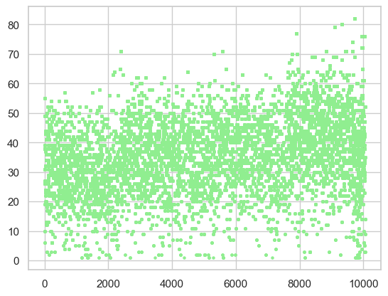

```python
plt.scatter(x = df1['idll_vo3lv'], y= df1['score'], s=5, color = "lightgreen")
```

This graph shows that there is a rather wide range in the number unique patterns that students were able to create. It's also clear that the majority of students were able to create 20 to 40 different patterns.

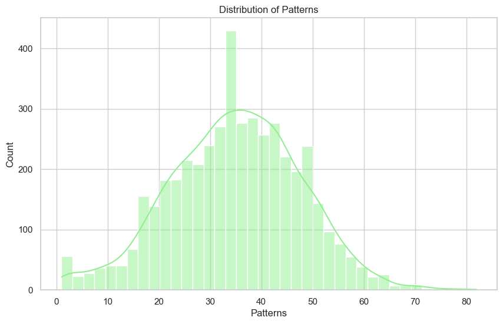

```python
# Create the DataFrame with grouped data
df_resultstudents = df1.groupby('idll_vo3lv')['patternsm'].nunique().reset_index()

# Set figure size and style
plt.figure(figsize=(10, 6))
sns.set(style='whitegrid')

# Create and customize the histogram
sns.histplot(data=df_resultstudents, x="patternsm", kde=True, color="lightgreen")

# Set labels and title
plt.xlabel("Patterns")
plt.ylabel("Count")
plt.title("Distribution of Patterns")
```

It is clear from this graph that the scores have a normal distribution. In fact, you can see that a great deal of scores fall between 30 and 45, peaking at 35.